# FML Assignment_Universal Bank

Nitin Marwah

2024-02-23

Problem Statement-: The Universal Bank, a dynamic and expanding financial institution, faces a strategic challenge in maximizing its loan business potential. While the majority of its customer base consists of liability customers, the bank’s asset customer segment remains relatively small. To fuel growth, the bank aims to capitalize on its existing customer relationships and convert liability customers into personal loan clients. Building on the success of a previous campaign, which achieved a notable 9% conversion rate, the bank’s retail marketing department seeks to refine targeting strategies for future initiatives. Leveraging machine learning techniques, specifically k-nearest neighbors (k-NN), the bank intends to predict customer acceptance of loan offers. The dataset, UniversalBank.csv, encompasses demographic information, banking associations, and responses to past loan campaigns for 5000 customers. With only 9.6% of customers accepting previous loan offers, the bank faces the challenge of effectively partitioning the data into training (60%) and validation (40%) sets to develop robust predictive models.

```r
library(dplyr)
library(e1071)
library(lattice)
library(caret)
```

```r
library(class)
library(ggplot2)
universal_bank <- read.csv("/Applications/UniversalBank.csv")
summary(universal_bank)
```

```
##        ID            Age          Experience       Income          ZIP.Code
##  Min.   :   1   Min.   :23.00   Min.   :-3.0   Min.   :  8.00   Min.   : 9307
##  1st Qu.:1251   1st Qu.:35.00   1st Qu.:10.0   1st Qu.: 39.00   1st Qu.:91911
##  Median :2500   Median :45.00   Median :20.0   Median : 64.00   Median :93437
##  Mean   :2500   Mean   :45.34   Mean   :20.1   Mean   : 73.77   Mean   :93152
##  3rd Qu.:3750   3rd Qu.:55.00   3rd Qu.:30.0   3rd Qu.: 98.00   3rd Qu.:94608
##  Max.   :5000   Max.   :67.00   Max.   :43.0   Max.   :224.00   Max.   :96651
##      Family          CCAvg          Education        Mortgage
##  Min.   :1.000   Min.   : 0.000   Min.   :1.000   Min.   :  0.0
##  1st Qu.:1.000   1st Qu.: 0.700   1st Qu.:1.000   1st Qu.:  0.0
##  Median :2.000   Median : 1.500   Median :2.000   Median :  0.0
##  Mean   :2.396   Mean   : 1.938   Mean   :1.881   Mean   : 56.5
##  3rd Qu.:3.000   3rd Qu.: 2.500   3rd Qu.:3.000   3rd Qu.:101.0
##  Max.   :4.000   Max.   :10.000   Max.   :3.000   Max.   :635.0
##  Personal.Loan   Securities.Account   CD.Account         Online
##  Min.   :0.000   Min.   :0.0000     Min.   :0.0000   Min.   :0.0000
##  1st Qu.:0.000   1st Qu.:0.0000     1st Qu.:0.0000   1st Qu.:0.0000
##  Median :0.000   Median :0.0000     Median :0.0000   Median :1.0000
##  Mean   :0.096   Mean   :0.1044     Mean   :0.0604   Mean   :0.5968
##  3rd Qu.:0.000   3rd Qu.:0.0000     3rd Qu.:0.0000   3rd Qu.:1.0000
##  Max.   :1.000   Max.   :1.0000     Max.   :1.0000   Max.   :1.0000
##    CreditCard
##  Min.   :0.000
##  1st Qu.:0.000
##  Median :0.000
##  Mean   :0.294
##  3rd Qu.:1.000
##  Max.   :1.000
```

```r
#Drop-ID and ZIP.Code
universal_bank <- universal_bank[,-c(1,5)]
```

```r
#Convert categorical variables into dummy variables.
#Only Education is to be converted
universal_bank$Education <- as.factor(universal_bank$Education)
groups <- dummyVars(~., data = universal_bank)
universal_dm <- as.data.frame(predict(groups,universal_bank))
```

```r
#split the data into training (60%) and validation (40%) sets
set.seed(1)
train.index <- sample(row.names(universal_dm), 0.6*dim(universal_dm)[1])
valid.index <- setdiff(row.names(universal_dm), train.index)
train.df <- universal_dm[train.index,]
valid.df <- universal_dm[valid.index,]
#Normalize the data
train.norm.df <- train.df[,-10]
valid.norm.df <- valid.df[,-10]
norm.values <- preProcess(train.df[, -10], method=c("center", "scale"))
train.norm.df <- predict(norm.values, train.df[, -10])
valid.norm.df <- predict(norm.values, valid.df[, -10])
```

Question 1 - Age = 40, Experience = 10, Income = 84, Family = 2, CCAvg = 2, Education_1 = 0, Education_2 = 1, Education_3 = 0, Mortgage = 0, Securities Account = 0, CD Account = 0, Online = 1, and Credit Card = 1. Perform a k-NN classification with all predictors except ID and ZIP code using k = 1. Remember to transform categorical predictors with more than two categories into dummy variables first. Specify the success class as 1 (loan acceptance), and use the default cutoff value of 0.5. How would this customer be classified?

```r
#Let’s create a new sample
new_customer <- data.frame(Age = 40, Experience = 10, Income = 84, Family = 2, CCAvg = 2, Education.1 = 0,Education.2 = 1, Education.3 = 0, Mortgage = 0,Securities.Account = 0, CD.Account = 0, Online = 1, CreditCard = 1)
#Normalizing the new customer(sample)
new.cust.norm <- new_customer
new.cust.norm <- predict(norm.values, new.cust.norm)
#Using K-NN to Predict
knn_pred <- class::knn(train = train.norm.df, test = new.cust.norm, cl = train.df$Personal.Loan, k = 1)
knn_pred
```

```
## [1] 0
## Levels: 0 1
```

Question 2 - What is a choice of k that balances between overfitting and ignoring the predictor information?

```r
#To calculate the accuracy for each value of k
#To set the range of k values to consider
accuracy.df <- data.frame(k = seq(1, 20, 1), overallaccuracy = rep(0, 20))
for(i in 1:20)
{knn.pred <- class::knn(train = train.norm.df,
test = valid.norm.df,
cl = train.df$Personal.Loan, k = i)
accuracy.df[i, 2] <- confusionMatrix(knn.pred,as.factor(valid.df$Personal.Loan),positive = "1")$overall[1]
}
which(accuracy.df[,2] == max(accuracy.df[,2]))
```

```
## [1] 3
```

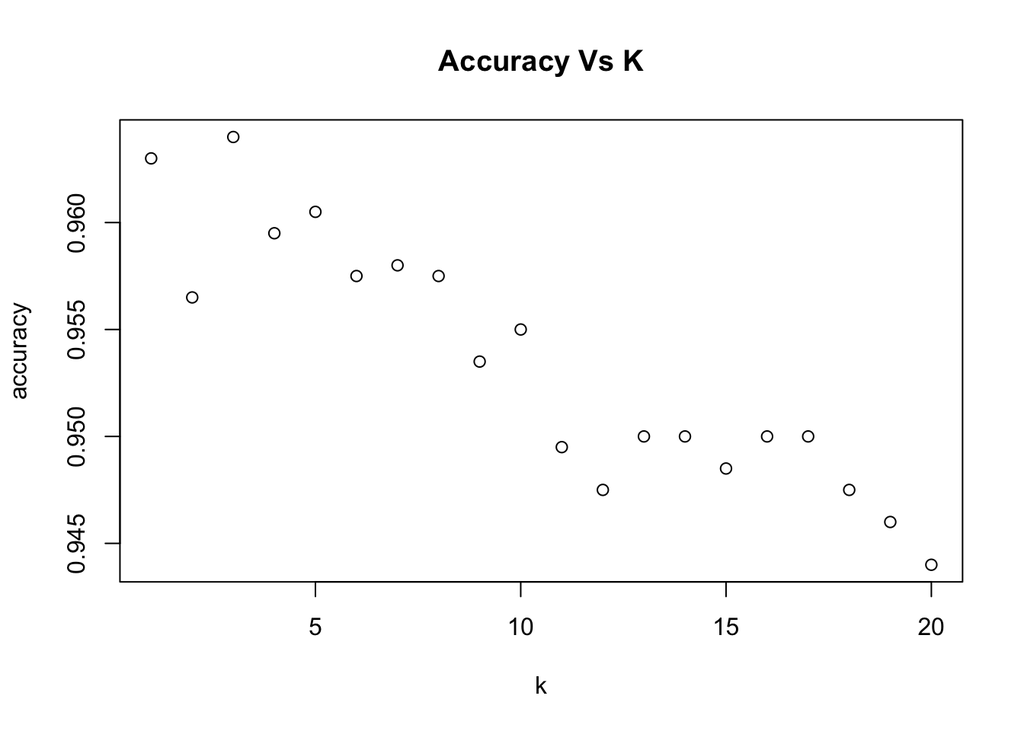

```r
plot(accuracy.df$k,accuracy.df$overallaccuracy, main = "Accuracy Vs K", xlab = "k", ylab = "accuracy")
```

Question 3 - Show the confusion matrix for the validation data that results from using the best k.

```r
knn.pred <- class::knn(train = train.norm.df,
test = valid.norm.df,
cl = train.df$Personal.Loan, k = 3)
confusionMatrix(knn.pred,as.factor(valid.df$Personal.Loan),positive = "1")$table
```

```
##           Reference
## Prediction    0    1
##          0 1786   63
##          1    9  142
```

Question 4 - Consider the following customer: Age = 40, Experience = 10, Income = 84, Family = 2, CCAvg = 2, Education_1 = 0, Education_2 = 1, Education_3 = 0, Mortgage = 0, Securities Account = 0, CD Account = 0, Online = 1 and Credit Card = 1. Classify the customer using the best k.

```r
#Loading new customer profile
new_customer2<-data.frame( Age = 40, Experience = 10, Income = 84, family =2, CCAvg = 2, Education_1 = 0, Education_2 = 1, Education_3 = 0, Mortgage = 0, Securities.Account = 0, CDAccount = 0, Online = 1, CreditCard = 1)
#Using K-NN to Predict
knn_pred <- class::knn(train = train.norm.df, test = new.cust.norm, cl = train.df$Personal.Loan, k = 3)
knn_pred
```

```
## [1] 0
## Levels: 0 1
```

```r
# As result below exhibit- 0, Customer is classified as Loan Rejected
```

Question 5 - Repartition the data, this time into training, validation, and test sets (50% : 30% : 20%). Apply the k-NN method with the k chosen above. Compare the confusion matrix of the test set with that of the training and validation sets. Comment on the differences and their reason. Spilitting Data- 50% (training) 30% (Validation) 20% (Testing)

```r
set.seed(1)
Train_Index1 <- sample(row.names(universal_dm), 0.5*dim(universal_dm)[1])
Val_Index1 <- sample(setdiff(row.names(universal_dm),Train_Index1),0.3*dim(universal_dm)[1])
Test_Index1 <-setdiff(row.names(universal_dm),union(Train_Index1,Val_Index1))
Train_Data <- universal_dm[Train_Index1,]
Validation_Data <- universal_dm[Val_Index1,]
Test_Data <- universal_dm[Test_Index1,]
#Normalize the data
train.norm.df1 <- Train_Data[,-10]
valid.norm.df1 <- Validation_Data[,-10]
Test.norm.df1 <-Test_Data[,-10]
norm.values1 <- preProcess(Train_Data[, -10], method=c("center", "scale"))
train.norm.df1 <- predict(norm.values1, Train_Data[,-10])
valid.norm.df1 <- predict(norm.values1, Validation_Data[,-10])
Test.norm.df1 <-predict(norm.values1,Test_Data[,-10])
#Using K-NN to Predict
validation_knn = class::knn(train = train.norm.df1, test = valid.norm.df1, cl = Train_Data$Personal.Loan, k = 3)
test_knn = class::knn(train = train.norm.df1, test = Test.norm.df1, cl = Train_Data$Personal.Loan, k = 3)
Train_knn = class::knn(train = train.norm.df1, test = train.norm.df1, cl = Train_Data$Personal.Loan, k = 3)
#Performing Validation confusion Matrix
validation_confusion_matrix = confusionMatrix(validation_knn, as.factor(Validation_Data$Personal.Loan), positive = "1")$table
validation_confusion_matrix
```

```
##           Reference
## Prediction    0    1
##          0 1358   42
##          1    6   94
```

```r
#Performing Test confusion Matrix
test_confusion_matrix = confusionMatrix(test_knn, as.factor(Test_Data$Personal.Loan), positive = "1")$table
test_confusion_matrix
```

```
##           Reference
## Prediction   0   1
##          0 884  35
##          1   4  77
```

```r
#Performing Train confusion Matrix
Training_confusion_matrix = confusionMatrix(Train_knn, as.factor(Train_Data$Personal.Loan), positive = "1")$table
Training_confusion_matrix
```

```
##           Reference
## Prediction    0    1
##          0 2263   54
##          1    5  178
```